# Ejercicio_1

Gabriela Chavez

2026-08-11

### Exercise 1

- Define the initial conditions and parameters for an SEIR model where the total population is 1000, the initial exposed population is 5, the initial infected population is 0, and the initial recovered population is 0. The transmission rate (β) is 0.003, the incubation rate (σ) is 0.2, and the recovery rate (γ) is 0.1. Create the vectors for these initial conditions and parameters in R.

```r
initial_conditions <- c(S=995, E=5, I=0, R=0)

initial_conditions
```

```
##   S   E   I   R
## 995   5   0   0
```

```r
parameters <- c( beta=0.003, sigma=0.2, gamma=0.1)
parameters
```

```
##  beta sigma gamma
## 0.003 0.200 0.100
```

### Exercise 2

- Write an R function called seir_model that represents the differential equations for the SEIR model. Use the structure of the SIR model function provided in the lesson and the SEIR conceptual diagram below as a reference.

```r
seir_model <- function(time, state, parameters){
   with(as.list(c(state,parameters)), {
     dS <- -beta * S * E
     dE <- beta * S * I  - sigma * E
     dI <- sigma * E  - gamma * I
     dR <- gamma * I

  list(c(dS,dE,dI,dR))
  })
}
```

### Exercise 3

- Use the ode function from the {deSolve} package to solve the differential equations for the initial conditions and parameters defined in Exercise 1. Set the time span for the simulation to 50 days.

```r
library(deSolve)
time <- seq(1, 50, by=1)
seir_out <- ode(
  # inital state
  y = initial_conditions,
  # sequence of time points
  times = time,
  # model function
  func = seir_model,
  # parameters in the model
  parms = parameters
)
```

### Exercise 4

Visualize the results of the SEIR model solution from Exercise 3 using ggplot2. Plot the number of susceptible, exposed, infected, and recovered individuals over time on the same graph with different colors for each compartment.

```r
library(ggplot2)
seir_outs <- as.data.frame(seir_out)
seir_outs
```

```
##    time          S           E           I            R
## 1     1 995.000000   5.0000000   0.0000000   0.00000000
## 2     2 980.242609   5.4083879   0.9486583   0.04751753
## 3     3 960.747825   8.4414391   2.1376066   0.19777890
## 4     4 928.807862  14.7577302   4.0891404   0.50025346
## 5     5 875.012127  26.0255724   7.5030316   1.06398000
## 6     6 788.799000  44.5153019  13.3988861   2.08320705
## 7     7 663.946162  71.8440774  23.0988581   3.87057506
## 8     8 508.752360 106.4689471  37.8465119   6.87222753
## 9     9 350.223319 141.8070740  57.9898121  11.62167748
## 10   10 219.125371 168.7530615  82.2637543  18.60954741
## 11   11 129.071456 181.6123670 108.0338771  28.12453337
## 12   12  74.723621 180.7666499 132.4269204  40.16946203
## 13   13  44.054767 170.2585078 153.3283539  54.49229798
## 14   14  27.043149 154.5208832 169.6718039  70.68224900
```

[output cut: 36 more lines]

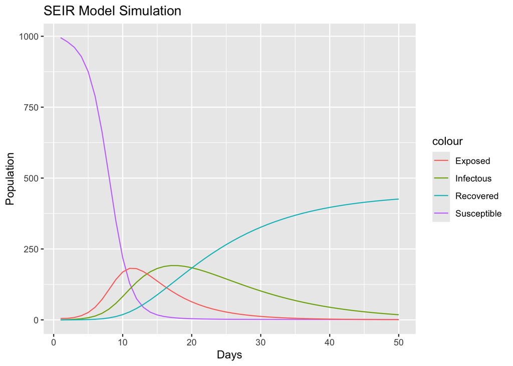

```r
seir_plot <- ggplot(seir_outs, aes(x=time)) +
  geom_line(aes(y= S, color ="Susceptible"))+
  geom_line(aes(y=I, color ="Infectous"))+
  geom_line(aes(y=E, color= "Exposed"))+
  geom_line(aes(y=R, color = "Recovered")) +
  labs(title = "SEIR Model Simulation", x = "Days", y = "Population")

seir_plot
```

### ¿Qué condición debe cumplirse para que el número de personas infecciosas aumente al inicio del brote?

**R:** B tiene que ser alta y que toda la población sea susceptible, pues si hay una tasa de transmisión muy baja la probabilidad de que el número de personas aumente es muy baja

### Calcula R_0 usando los valores de beta, gamma y N de la simulación

```r
R0 <- parameters["beta"]/parameters["gamma"]
R0
```

```
## beta
## 0.03
```

### Calcula la proporción crítica de personas susceptibles

```r
ps <- 1/R0
ps
```

```
##     beta
## 33.33333
```

### Consideras que el modelo SIR representa adecuadamente el brote obrservado, argumenta tu respuesta

**Posible mejora** - Considerar que no todos los susceptibles se van a infectar

### Ejecuta el modelo SEIR construído en los ejercicios anteriores

#### Modifica el parámetro sigma usando, por ejemplo, sigma=0.1,0,2,0.5

#### Para el cada valor registra:

-El día del pico de infecciosos -El número máximo de infecciosos; -La duración del brote

[output not shown]